# Project 5 – EMRAM Maturity Audit Report (Stages 0 to 4)

```r
knitr::opts_chunk$set(echo = TRUE, warning = FALSE, message = FALSE)
library(tidyverse)
library(scales)
```

```r
library(ggplot2)
library(forcats)
```

## 1 Introduction

The Electronic Medical Record Adoption Model (EMRAM) is a staged framework used to assess hospital EMR maturity. Stages 0 to 4 represent foundational phases, from limited digital capability to structured clinical documentation and early clinical integration.

This project applies a checklist based EMRAM audit to a single hospital and documents the workflow in a reproducible R pipeline.

## 2 Methods

### 2.1 Study design

Descriptive EMRAM maturity assessment using a checklist aligned to HIMSS EMRAM stages 0 to 4. Each criterion was rated as implemented (Yes), partially implemented (Partial), or not implemented (No). Evidence fields captured supporting information where available.

### 2.2 Data source

The dataset is an EMRAM audit export where rows represent criteria and columns store stage, indicator text, response, and evidence.

Scoring and stage assignment Responses were mapped:

Yes = 1

Partial = 0.5

No = 0

Stage achievement followed cumulative EMRAM rules. A stage was considered achieved only if all criteria in that stage were fully implemented (score equal to 1). The final EMRAM stage was the highest stage achieved.

Because clinical decision support systems are absent in this setting, CDSS related items were scored as not implemented.

### 2.3 Analysis

Analysis steps:

Stage wise summaries of item counts and proportion fully implemented

Domain level summaries based on simple text based domain tagging

Visualizations for stage scores, domain profiles, and item level compliance

All steps were implemented in R with separate R Markdown files for cleaning, scoring, and reporting.

## 3 Results

```r
stage_summary <- read_csv("data/emram_stage_summary.csv")
domain_summary <- read_csv("data/emram_domain_summary.csv")
final_stage <- read_csv("data/emram_final_stage.csv")$final_stage[1]

stage_summary
```

```
## # A tibble: 5 × 7
##   stage   n_items n_yes n_partial  n_no pct_yes stage_complete
##   <chr>     <dbl> <dbl>     <dbl> <dbl> <chr>            <dbl>
## 1 Stage 0       1     0         0     1 0.0%                 0
## 2 Stage 1       1     1         0     0 100.0%               1
## 3 Stage 2       1     1         0     0 100.0%               1
## 4 Stage 3       1     0         0     1 0.0%                 0
## 5 Stage 4       1     0         0     1 0.0%                 0
```

```r
domain_summary
```

```
## # A tibble: 3 × 4
##   domain        n_items mean_score pct_yes
##   <chr>           <dbl>      <dbl> <chr>
## 1 Other               3      0.667 66.7%
## 2 CDSS                1      0     0.0%
## 3 Documentation       1      0     0.0%
```

```r
final_stage
```

```
## [1] "Stage 2"
```

### 3.1 Stage completion

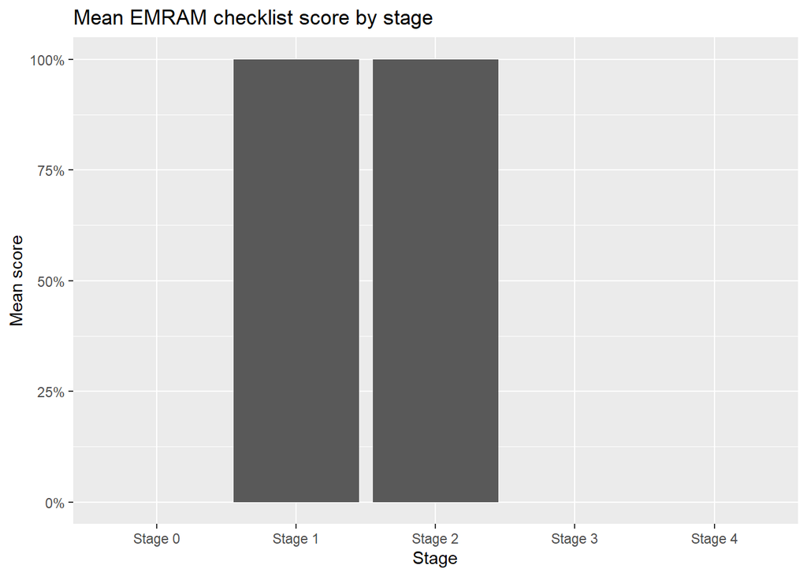

```r
stage_plot_df <- stage_summary %>%
mutate(mean_score = (n_yes + 0.5 * n_partial) / n_items)

ggplot(stage_plot_df, aes(x = factor(stage), y = mean_score)) +
geom_col() +
scale_y_continuous(limits = c(0, 1), labels = percent_format(accuracy = 1)) +
labs(
title = "Mean EMRAM checklist score by stage",
x = "Stage",
y = "Mean score"
)
```

### 3.2 Domain maturity profile

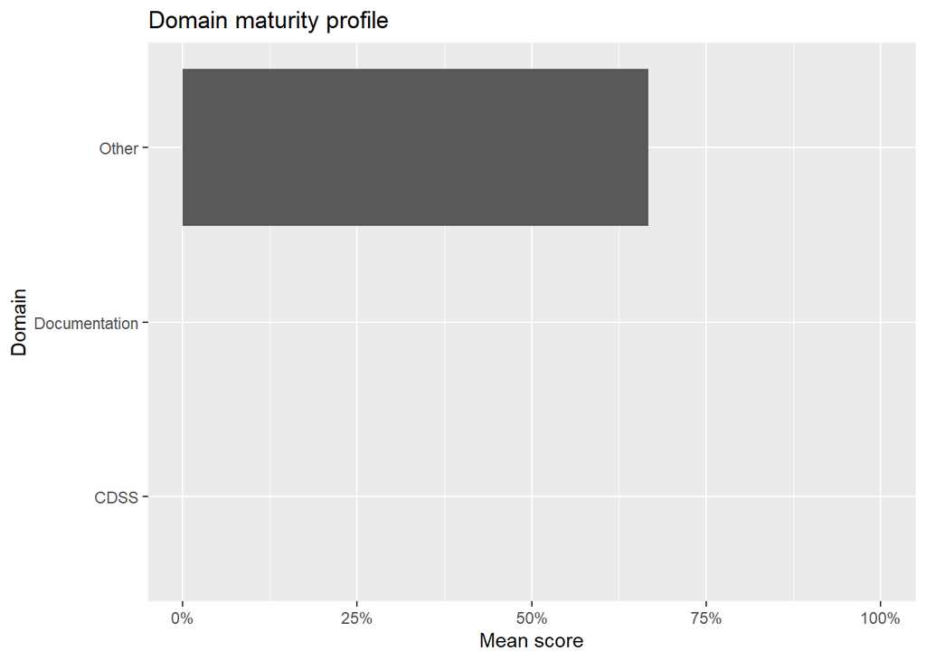

```r
ggplot(domain_summary, aes(x = reorder(domain, mean_score), y = mean_score)) +
geom_col() +
coord_flip() +
scale_y_continuous(limits = c(0, 1), labels = percent_format(accuracy = 1)) +
labs(
title = "Domain maturity profile",
x = "Domain",
y = "Mean score"
)
```

### 3.3 Indicator compliance heatmap

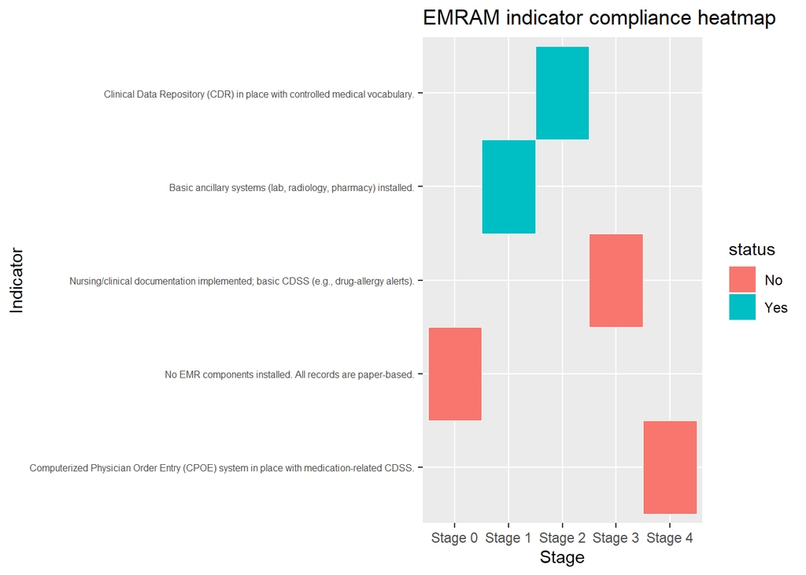

```r
emram_clean <- read_csv("data/emram_clean.csv") %>%
mutate(
status = case_when(
score == 1 ~ "Yes",
score == 0.5 ~ "Partial",
score == 0 ~ "No",
TRUE ~ "Missing"
)
)

ggplot(emram_clean, aes(
x = factor(stage),
y = fct_reorder(indicator, score, .fun = mean, na.rm = TRUE),
fill = status
)) +
geom_tile(color = "white") +
labs(
title = "EMRAM indicator compliance heatmap",
x = "Stage",
y = "Indicator"
) +
theme(axis.text.y = element_text(size = 6))
```

## 5 Recommendations

- Prioritise implementation of basic rules based CDSS for allergy, interaction, and guideline prompts.
- Strengthen CPOE and eMAR integration to support safer medication workflows.
- Formalise EMR governance and include regular EMRAM based audits in quality routines.
- Use this baseline as a reference point for future upgrades and budget planning.